# Is there a heat island generated by Eugene, Oregon?

# Analysis of temperature variation in and around the city

-Damian Satterthwaite-Phillips

## Introduction

As a result of various types of pavement, and building materials, as well as a lack of shade, many urban areas produce more heat than the areas around them. This may contribute to global warming, as well as creating heat levels that may negatively affect the residents.

Here we investigate the possibility that the city of Eugene, OR may be producing heat levels higher than the surrounding areas.

The data used in this analysis come from the [PRISM Climate Data](http://www.prism.oregonstate.edu/), and were downloaded and extracted with the help of [prism package for R](https://github.com/ropensci/prism) written by [Edmund (Ted) Hart](https://github.com/emhart). At the time of this writing (Sep 2015), the package is still under development. It is likely to be availbale through [The Comprehensive R Network (CRAN)](https://cran.r-project.org/) soon, but until then, refer to the github repo for directions on downloading and usage.

The PRISM data come from a grid of kriged (interpolated) data points, ultimately from various sources of meteorlogical data (see their site for details). The data used here are from a grid of points spaced at approximately 4 km intervals in and around Eugene. The approximate location of these data points may be seen [here](http://phillips-research.com/uhi/map.html). For quick reference to individual point locations, the individual loci are numbered 1 - 270, with 1 being the lower-leftmost point (SW corner), and continuning up, with 10 stations per column. Hence the left-/western-most column of data points are 1 - 10, the next column, 11 - 20, and so forth.

The PRISM data used here are, precipitation in mm ('ppt'), minimum and maximum temperature in degrees C ('tmin', 'tmax'), and “mean temperature” ('temp'), which is just the mean of the minimum and maximum, for every day of 2014. Additionally, elevation data were obtained from [geoplaner.com](http://www.geoplaner.com/), which ultimately gets the data from the Shuttle Radar Topography Mission conducted by NASA.

## TO DO

- Describe the methods for downloading and formatiing the data.
- Describe methods for creating additional variables.

The data set is available to download [here](https://drive.google.com/file/d/0B0G-SVXyqWzwV2tvSVZkeHk2UFk/view?usp=sharing) (22.3 MB). The variables are as follows:

- date: date in ‘yyyy-mm-dd’ format
- ppt: preciptiation in mm
- tmin: minimum temperature for the point for the day (°C)
- tmax: maximum temperature for the point for the day (°:C)
- temp: “mean” temperature fot the point for the day (tmin + tmax) / 2 (°C)
- x: longitude in decimal form
- y: latitude in decimal form
- station: data point location in (lon, lat) = (x, y) format; also referred to in the analysis as “locus”
- ID: a unique number to identify each geographic point from which data were obtained from PRISM (see explanation of numbering)
- elev: elevation (m above sea level)
- adjWater: boolean: TRUE if locus is adjacent to the Fern Ridge Lake, or the Willamette, or Mackenzie rivers
- distCC: “Distance from city center” (arbitrarily chosen as a point on 11th Ave, midway between Washington and Jefferson Streets)
- tminDiff: the change in tmin from the previous day at the same locus (°C)
- tmaxDiff: the change in tmax from the previous day at the same locus (°C)
- tempDiff: the change in temp from the previous day at the same locus (°C)
- pptT: transformation of ppt to more closely approximate a normal distribution (= ppt<sup>0.2</sup>)
- elevT: transformation of elev to more closely approximate a normal distribution (= elev<sup>-0.17</sup>)
- inCity: boolean: TRUE if locus is within Eugene or Springfield city limits (approximate)
- areaMedTemp: median temperature for the day across all loci; i.e., median of all temp values for the day (°C)
- tempIrreg: difference in the temperature of the locus from the area median for the day (= temp - areaMedTemp); i.e., a negative value indicates a temperature below the area median

## Preliminary Analysis

First load the data:

```r
# The following line of code clears memory. You will lose any unsaved objects in memory!
rm(list = ls())

# Replace path below to wherever you save the data file
eug = read.csv('~/Desktop/PRA/uhi/dataComplied/eug2014.csv')

# Change IDs to factors
eug$ID = as.factor(eug$ID)

# Change the date to object of the Date class
eug$date = as.Date(eug$date, format = '%Y-%m-%d')

# Set default alpha (transparency) for plots
alpha = 0.01
years = '(2014)'
nStations = length(unique(eug$ID))

# The following identifies those data points that are within the city limits
cityLoci = c( 98, 106:108, 115:118, 125:128, 134:137, 145:147, 155, 156, 166,
              176, 186 )
```

### Visualizing the data

Before doing anything else, we do a sanity check of the data to be sure there are no problems.

#### Precipitation

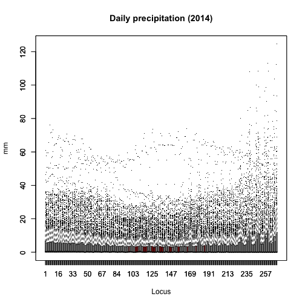

```r
# Examine precipitation Data

# Boxplots by data point
boxplot( eug$ppt[eug$inCity == F] ~ eug$ID[eug$inCity == F],
         main = paste('Daily precipitation', years),
         xlab = 'Locus', ylab = 'mm', pch = '.' )
boxplot( eug$ppt[eug$inCity == T] ~ eug$ID[eug$inCity == T], col = 2,
         pch = '.', xlab = '', ylab = '', add = T)
```

We see that the rainfall is similar across the region, but we notice the higher numbered data (those points at the far east of the region) generally have greater rainfall. This is the region at the base of the Cascades. All points typically have daily precipitation <20 mm, though most points have occasional days with over 50 mm, and some points as much as 120 mm in a single day. The data points within the city are shown in red, and do not have obvious differences from surrounding points.

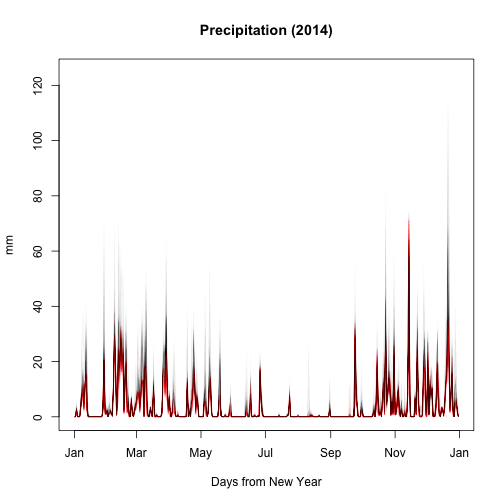

```r
# Precipitation by day of the year
plot( eug$ppt[eug$ID == 1] ~ eug$date[eug$ID == 1], type = 'l',
      ylim = range(eug$ppt), col = rgb(0, 0, 0, alpha),
      main = paste('Precipitation', years),
      xlab = 'Days from New Year', ylab = 'mm')

for (s in 2:nStations) {
    if (s %in% cityLoci) {
        color = rgb(1, 0, 0, alpha*10)
    } else {
        color = rgb(0, 0, 0, alpha)
    }
    lines(eug$ppt[eug$ID == s] ~ eug$date[eug$ID == s], col = color)
}
```

Here we see daily rainfall over the course of the year. Data points within the city are shown in red, and the remainder in black. Again, there is no readily apparent difference.

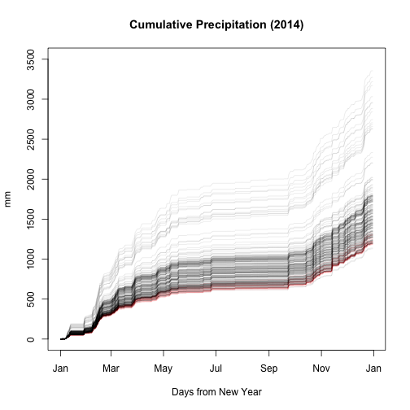

```r
# Compare cumulative amounts over the course of the year
plot( cumsum(eug$ppt[eug$ID == 1]) ~ eug$date[eug$ID == 1], type = 'l',
      col = rgb(0, 0, 0, 10*alpha),
      main = paste('Cumulative Precipitation', years),
      xlab = 'Days from New Year', ylab = 'mm', ylim = c(0, 3500))

for (s in 2:nStations) {
    if (s %in% cityLoci) {
        color = rgb(1, 0, 0, 10*alpha)
    } else {
        color = rgb(0, 0, 0, 10*alpha)
    }
    lines(cumsum(eug$ppt[eug$ID == s]) ~ eug$date[eug$ID == s], col = color)
}
```

Here we plot the *cumulative* rainfall over the course of the year. The data points in the city, shown in red, clearly got less total rainfall in 2014 than most other sites.

#### Temperature

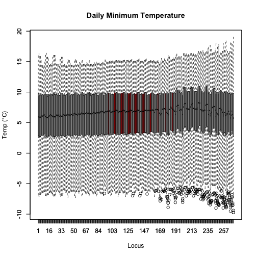

```r
# Examine temp Data
# tmin
plot( eug$tmin[eug$inCity == F] ~ eug$ID[eug$inCity == F],
      main = 'Daily Minimum Temperature', xlab = 'Locus',
      ylab = 'Temp (°C)' )
plot( eug$tmin[eug$inCity == T] ~ eug$ID[eug$inCity == T],
      xlab = '', ylab = '', col = 2, add = T)
```

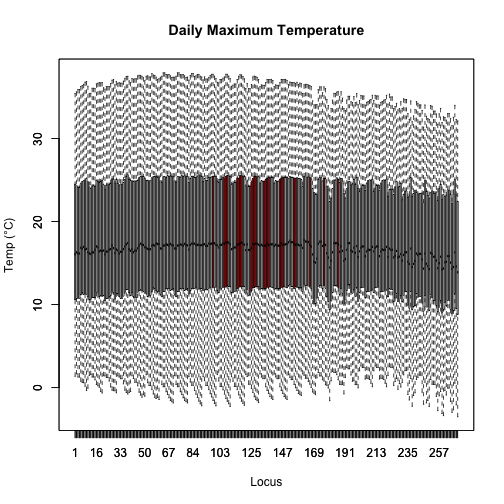

```r
# tmax
plot( eug$tmax[eug$inCity == F] ~ eug$ID[eug$inCity == F],
      main = 'Daily Maximum Temperature', xlab = 'Locus',
      ylab = 'Temp (°C)')
plot( eug$tmax[eug$inCity == T] ~ eug$ID[eug$inCity == T],
      xlab = '', ylab = '' , col = 2, add = T)
```

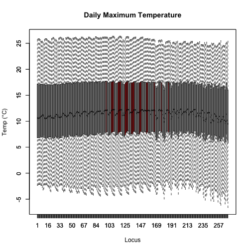

```r
# mean temp
plot( eug$temp[eug$inCity == F] ~ eug$ID[eug$inCity == F],
      main = 'Daily Maximum Temperature', xlab = 'Locus',
      ylab = 'Temp (°C)')
plot( eug$temp[eug$inCity == T] ~ eug$ID[eug$inCity == T],
      xlab = '', ylab = '', col = 2, add = T)
```

Data all look reasonable, and if city loci (in red) are different from the surrounding areas, it is not obvious.

Next, we plot the temperature at each of the loci as a heatmap for a number of days… namely, the 15th day of each month, to see if there are visibly discernible differences between the city loci and the others.

For reference, the Fern Ridge Lake and the Eugene airport are plotted as pointss (the lake is the more western point), along with a rectangle showing the approximate bounding box containing Eugene and the neighboring city of Springfield.

In the following heatmaps, the lowest temperatures for that day are shown in blue, and the highest temperatures in red. The range is provided in the legends.

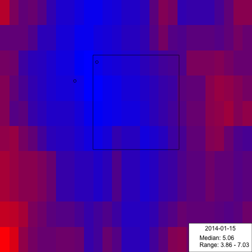

```r
# Look at data for some individual days as a heatmap

# Points to plot (lon, lat) = (x, y)
lake = c(-123.298, 44.094)
airport = c(-123.213, 44.121)
westB = -123.228
eastB = -122.896
northB = 44.131
southB = 43.996
xRange = range(eug$x)
yRange = range(eug$y)

# The image() function in R outputs a grid with dimensions 1 x 1, the following code scales the map dimensions to 1 x 1:
scaleX = function(x) {
    xDiff = diff(xRange)
    xOut = (x - xRange[1]) / xDiff
    xOut
}

scaleY = function(y) {
    yDiff = diff(yRange)
    yOut = (y - yRange[1]) / yDiff
    yOut
}

scaleXY = function(x, y) {
    return (c(scaleX(x), scaleY(y)))
}

airportScaled = scaleXY(airport[1], airport[2])
lakeScaled = scaleXY(lake[1], lake[2])

# A function that creates the heatmap for a given statistic (tmin, tmax, temp, or ppt) and a given date in 'yyyy-mm-dd' format
tempHM = function(stat, selectedDate) {
    hmData = subset(eug, date == selectedDate)
    datagrid = matrix(hmData[, stat], ncol = 27)
    par(mar = c(0, 0, 0, 0))
    image(t(datagrid), col = colorRampPalette(c('blue', 'red'))(40))
    points(airportScaled[1], airportScaled[2])
    points(lakeScaled[1], lakeScaled[2])
    polygon( scaleX(c(eastB, eastB, westB, westB)),
             scaleY(c(southB, northB, northB, southB)) )
    smed = median(hmData[, stat])
    smin = min(hmData[, stat])
    smax = max(hmData[, stat])

    legend( 'bottomright', title = selectedDate,
            legend = c( paste('Median:', round(smed, 2)),
                        paste( 'Range:', round(smin, 2), '-',
                               round(smax, 2) )))
}

# Generate heatmaps for the 15th day of each month of the year
tempHM('temp', '2014-01-15')
```

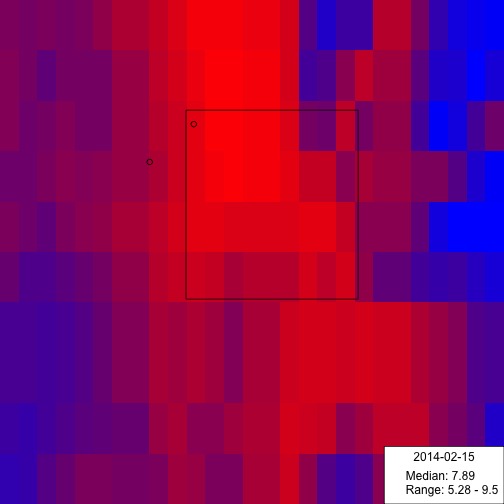

```r
tempHM('temp', '2014-02-15')
```

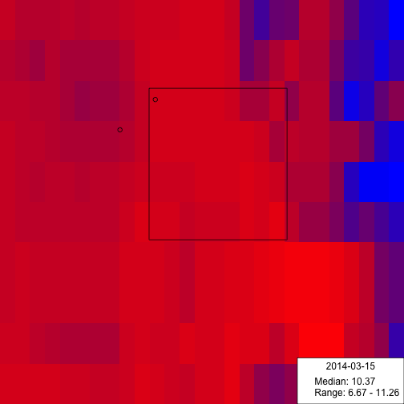

```r
tempHM('temp', '2014-03-15')
```

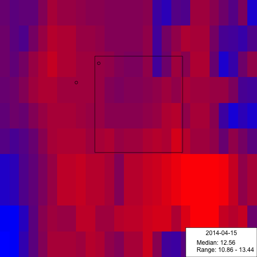

```r
tempHM('temp', '2014-04-15')
```

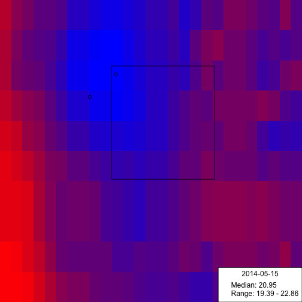

```r
tempHM('temp', '2014-05-15')
```

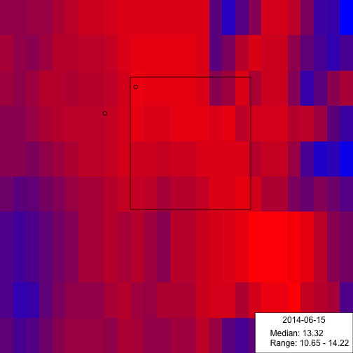

```r
tempHM('temp', '2014-06-15')
```

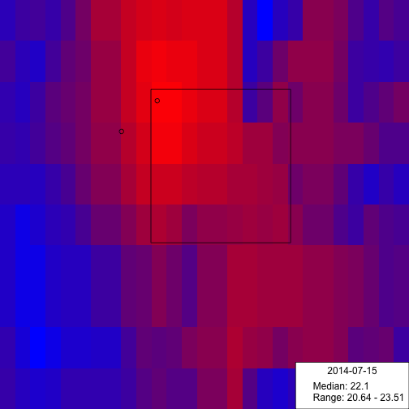

```r
tempHM('temp', '2014-07-15')
```

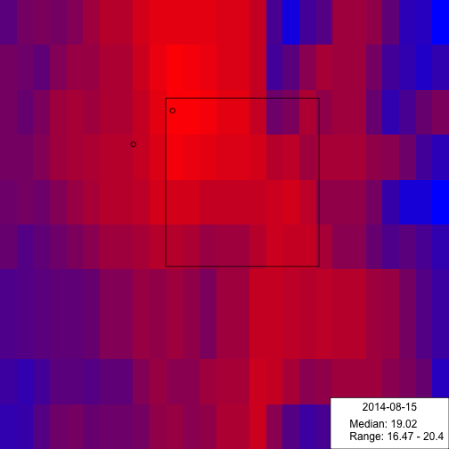

```r
tempHM('temp', '2014-08-15')
```

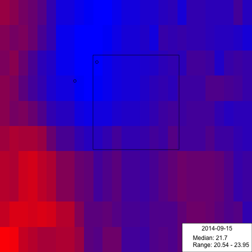

```r
tempHM('temp', '2014-09-15')
```

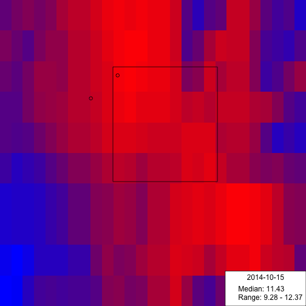

```r
tempHM('temp', '2014-10-15')
```

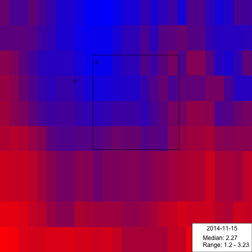

```r
tempHM('temp', '2014-11-15')
```

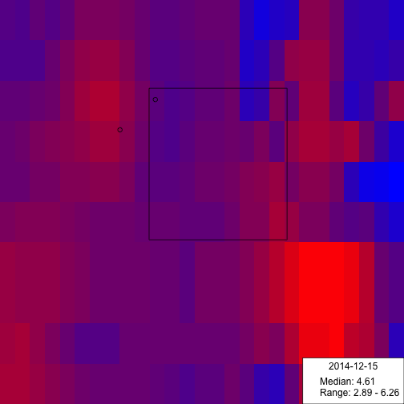

```r
tempHM('temp', '2014-12-15')
```

Just eyeballing these few days of data, there is no apparent evidence of a heat island produced by the city. On some days, the area within the city has higher temeratures than the surrounding area, but on others, the city region actually has *lower* temperatures than the surroundings.

Furthermore, there are a number of other variables that may be confounding the results. We already saw that precipitation is greater near the mountains. Similarly, Eugene lies in a valley with the coast range to the west, and the Cascades to the East. Finally, there is a large lake near the city, and two rivers that converge within the city, and these bodies of water may potentially have convective cooling effects in their vicinity. As such, we will need to model the temperature as a function of these variables, and then determine if there is a significant difference between those points nearer the city from those farther away.

The analysis continues here….